# RMarkdown.

**KEY VERSION**

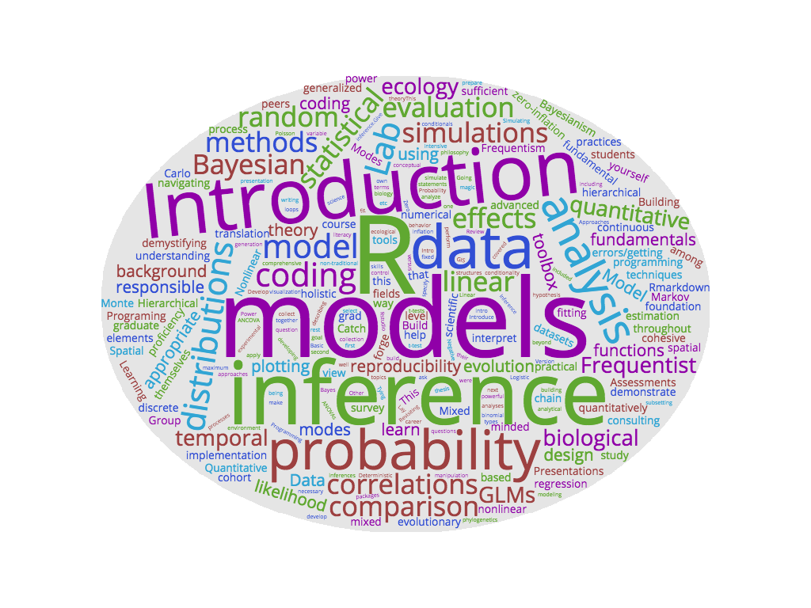

**This homework assignment will test your overall R know-how, and allow you to practice using RMarkdown.**

Complete the following tasks in a new R markdown script in R studio. For each question, first give a brief description (e.g., “Question 1: calculate the lowest miles/gallon in `mtcars`”), and then provide R code using `` "```" `` and the `echo = TRUE` argument. When finished, Knit your script together into an html report.

### Write code that completes the following tasks:

##### (1) What is the the lowest miles/gallon value listed in the the built in `mtcars` dataset? Print this value to the screen.

```r
min(mtcars$mpg)
```

```
## [1] 10.4
```

```r
# or
min(mtcars[,1])
```

```
## [1] 10.4
```

##### (2) Using the `mtcars` dataset, make a new dataframe called `cars.new` that has only two columns: the miles per gallon and the number of cylinders.

```r
cars.new <- data.frame(mtcars$mpg,mtcars$cyl)
# or
cars.new <-mtcars[,1:2]
```

##### (3) Write some code to sum the number of datapoints with ≥20mpg? (It’s kind of fun, because they can use a sum of booleans)

```r
sum(cars.new$mpg>=20)
```

```
## [1] 14
```

##### (4) In your new `cars.new` object, coerce the `cyl` column into a factor.

```r
cars.new$cyl <-as.factor(cars.new$cyl)
```

##### (5) Make a histogram (use = hist()) for mpg in `cars.new`.

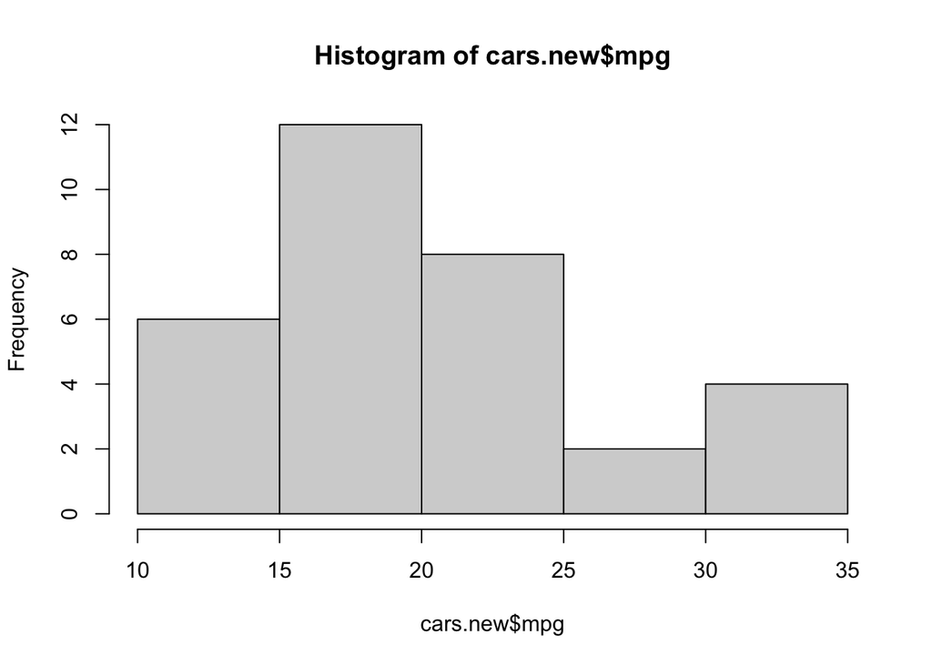

```r
hist(cars.new$mpg)
```

##### (6) Write a new function called `myFunc` that calculates the min, max, and mean of a vector, and returns those values in a new vector.

```r
myfunc <- function(xvec){
  xmin <- min(xvec)
  xmax <- max(xvec)
  xmean <- mean(xvec)
  return(c(xmin,xmax,xmean))
}
```

##### (7) Use your function to calculate the min, max, and mean of the first column in the `mtcars` dataset (mpg).

```r
myfunc(mtcars[,1])
```

```
## [1] 10.40000 33.90000 20.09062
```

##### (8) Write a `for loop` that uses your new function to caclulate the min, max, and mean for each column in the `mtcars` dataset, printing the answer to the screen as it goes.

```r
for (i in 1:ncol(mtcars)){
  print(myfunc(mtcars[,i]))
}
```

```
## [1] 10.40000 33.90000 20.09062
## [1] 4.0000 8.0000 6.1875
## [1]  71.1000 472.0000 230.7219
## [1]  52.0000 335.0000 146.6875
## [1] 2.760000 4.930000 3.596563
## [1] 1.51300 5.42400 3.21725
## [1] 14.50000 22.90000 17.84875
## [1] 0.0000 1.0000 0.4375
## [1] 0.00000 1.00000 0.40625
## [1] 3.0000 5.0000 3.6875
## [1] 1.0000 8.0000 2.8125
```

##### (9) Use the function `apply` to calculate the min, max, and mean of each column in `mtcars` using your new function `myfunc`.

```r
apply(mtcars,2,myfunc)
```

```
##           mpg    cyl     disp       hp     drat      wt     qsec     vs      am
## [1,] 10.40000 4.0000  71.1000  52.0000 2.760000 1.51300 14.50000 0.0000 0.00000
## [2,] 33.90000 8.0000 472.0000 335.0000 4.930000 5.42400 22.90000 1.0000 1.00000
## [3,] 20.09062 6.1875 230.7219 146.6875 3.596563 3.21725 17.84875 0.4375 0.40625
##        gear   carb
## [1,] 3.0000 1.0000
## [2,] 5.0000 8.0000
## [3,] 3.6875 2.8125
```